# R Introduction

# Exploratory Data Analysis

### dplyr package

- Seven basic commands:

  filter: filter rows by conditions

  slice: filter rows by index

  select: select columns

  arrange: sort rows

  mutate: create new variables

  summarise: create aggregations

  group_by: group by certain variables
- Joins: inner join, left join, right join, full join
- Window functions

### Pipe operator

- We need to use tons of parentheses in R to perform multiple operations in one command
- We can chain these operations one after another with the pipe operator:

  %>%

## What’s in our data: basic exploring

```r
library(dplyr)
```

```r
#str(affairs_full)
affairs_full %>% str()
```

```
## 'data.frame':    601 obs. of  19 variables:
##  $ id      : int  4 5 6 11 12 16 23 29 43 44 ...
##  $ male    : int  1 0 1 0 0 1 1 0 1 0 ...
##  $ age     : num  37 27 27 32 27 57 22 32 37 22 ...
##  $ yrsmarr : num  10 4 1.5 15 4 15 0.75 1.5 15 0.75 ...
##  $ kids    : int  0 0 0 1 1 1 0 0 1 0 ...
##  $ relig   : int  3 4 3 1 3 5 2 2 5 2 ...
##  $ educ    : int  18 14 18 12 17 18 17 17 18 12 ...
##  $ occup   : int  7 6 4 1 1 6 6 5 6 1 ...
##  $ ratemarr: int  4 4 4 4 5 5 3 5 2 3 ...
##  $ naffairs: int  0 0 3 0 3 0 0 0 7 0 ...
##  $ affair  : int  0 0 1 0 1 0 0 0 1 0 ...
##  $ vryhap  : int  0 0 0 0 1 1 0 1 0 0 ...
##  $ hapavg  : int  1 1 1 1 0 0 0 0 0 0 ...
##  $ avgmarr : int  0 0 0 0 0 0 1 0 0 1 ...
##  $ unhap   : int  0 0 0 0 0 0 0 0 1 0 ...
##  $ vryrel  : int  0 0 0 0 0 1 0 0 1 0 ...
##  $ smerel  : int  0 1 0 0 0 0 0 0 0 0 ...
##  $ slghtrel: int  1 0 1 0 1 0 0 0 0 0 ...
##  $ notrel  : int  0 0 0 0 0 0 1 1 0 1 ...
##  - attr(*, "datalabel")= chr ""
##  - attr(*, "time.stamp")= chr "22 May 2002 11:49"
##  - attr(*, "formats")= chr  "%9.0g" "%9.0g" "%9.0g" "%9.0g" ...
##  - attr(*, "types")= int  105 98 102 102 98 98 98 98 98 98 ...
##  - attr(*, "val.labels")= chr  "" "" "" "" ...
##  - attr(*, "var.labels")= chr  "identifier" "=1 if male" "in years" "years married" ...
##  - attr(*, "version")= int 6
```

```r
#head(affairs_full,5)
affairs_full %>% head(5)
```

```
##   id male age yrsmarr kids relig educ occup ratemarr naffairs affair
## 1  4    1  37    10.0    0     3   18     7        4        0      0
## 2  5    0  27     4.0    0     4   14     6        4        0      0
## 3  6    1  27     1.5    0     3   18     4        4        3      1
## 4 11    0  32    15.0    1     1   12     1        4        0      0
## 5 12    0  27     4.0    1     3   17     1        5        3      1
##   vryhap hapavg avgmarr unhap vryrel smerel slghtrel notrel
## 1      0      1       0     0      0      0        1      0
## 2      0      1       0     0      0      1        0      0
## 3      0      1       0     0      0      0        1      0
## 4      0      1       0     0      0      0        0      0
## 5      1      0       0     0      0      0        1      0
```

```r
#tail(affairs_full,5)
affairs_full %>% tail(5)
```

```
##       id male age yrsmarr kids relig educ occup ratemarr naffairs affair
## 597 9001    1  47      15    0     4   14     5        4        0      0
## 598 9010    0  32      15    1     3   14     1        5        1      1
## 599 9012    1  37      10    1     2   18     6        2        0      0
## 600 9023    1  37      15    1     3   17     5        4        0      0
## 601 9029    0  27       4    1     2   16     1        4        0      0
##     vryhap hapavg avgmarr unhap vryrel smerel slghtrel notrel
## 597      0      1       0     0      0      1        0      0
## 598      1      0       0     0      0      0        1      0
## 599      0      0       0     1      0      0        0      1
## 600      0      1       0     0      0      0        1      0
## 601      0      1       0     0      0      0        0      1
```

```r
#fix(affairs_full)
```

## Keeping, dropping columns, rows

#### R has powerful indexing features for accessing object elements.

#### These features can be used to select and exclude variables and observations.

```r
#Keep columns from 1st to 9th
#affairs2 <- affairs_full[,c(1,10)]
affairs1 <- affairs_full %>% select(1:9)
affairs1 %>% head(5)
```

```
##   id male age yrsmarr kids relig educ occup ratemarr
## 1  4    1  37    10.0    0     3   18     7        4
## 2  5    0  27     4.0    0     4   14     6        4
## 3  6    1  27     1.5    0     3   18     4        4
## 4 11    0  32    15.0    1     1   12     1        4
## 5 12    0  27     4.0    1     3   17     1        5
```

```r
#Version 1: Keep only the ID columns and the number of affairs
#affairs2 <- affairs_full[,c(1,10)]
affairs2 <- affairs_full %>% select(1,10)
affairs2 %>% head(5)
```

```
##   id naffairs
## 1  4        0
## 2  5        0
## 3  6        3
## 4 11        0
## 5 12        3
```

```r
#Version2: Keep only the ID columns and the number of affairs
#affairs2 <- affairs_full[,c("id","naffairs")]
affairs2 <- affairs_full %>% select("id","naffairs")
affairs2 %>% head(5)
```

```
##   id naffairs
## 1  4        0
## 2  5        0
## 3  6        3
## 4 11        0
## 5 12        3
```

```r
# Keep the first 10 rows and first 2 columns
#affairs_junk <- affairs_full[1:10,1:2]
affairs_junk <- affairs_full %>% select(1:10) %>% slice(1:2)

#Conditional
#affairs_junk <- affairs_full[(affairs_full$relig <= 3 & affairs_full$occup >=2),]
affairs_junk <- affairs_full %>% filter(relig<=3, occup >= 2)

# alternatively
affairs_junk <- affairs_full %>% filter(relig<=3 & occup >= 2)

# "or" condition instead of "and" condition
affairs_junk <- affairs_full %>% filter(relig<=3 | occup >= 2)
```

```r
# Use the "in" statement
affairs_junk <- affairs_full %>% filter(occup %in% c(4,6,7))
```

## Duplicated values

```r
# Check for duplicated values
#nrow(affairs_full[duplicated(affairs_full),])
affairs_full %>% duplicated() %>% sum()
```

```
## [1] 0
```

```r
#affairs_dup <- rbind(affairs_full,affairs_full[1,])
affairs_dup <- affairs_full %>% slice(1) %>% rbind(affairs_full)
affairs_dup %>% duplicated() %>% sum()
```

```
## [1] 1
```

```r
affairs_dup %>% group_by_all() %>% filter(n()>1)
```

```
## # A tibble: 2 x 19
## # Groups:   id, male, age, yrsmarr, kids, relig, educ, occup, ratemarr,
## #   naffairs, affair, vryhap, hapavg, avgmarr, unhap, vryrel, smerel,
## #   slghtrel, notrel [1]
##      id  male   age yrsmarr  kids relig  educ occup ratemarr naffairs
##   <int> <int> <dbl>   <dbl> <int> <int> <int> <int>    <int>    <int>
## 1     4     1    37      10     0     3    18     7        4        0
## 2     4     1    37      10     0     3    18     7        4        0
## # ... with 9 more variables: affair <int>, vryhap <int>, hapavg <int>,
## #   avgmarr <int>, unhap <int>, vryrel <int>, smerel <int>,
## #   slghtrel <int>, notrel <int>
```

```r
# Drop duplicated values
#affairs_non_dup<- affairs_dup[!duplicated(affairs_dup),]
affairs_non_dup <- affairs_dup %>% distinct(,.keep_all= TRUE)
affairs_non_dup %>% dim()
```

```
## [1] 601  19
```

## Joining datasets

```r
# Base R commands
#append datasets
#affairs_small <- rbind(head(affairs_full,20),affairs_full[120:142,])
affairs_small <- affairs_full %>%
  head(20) %>%
  rbind(affairs_full %>% slice(120:142))


# Simple join
#affairs_m0 <- cbind(affairs1,affairs2)
affairsm0 <- affairs1 %>% cbind(affairs2)

# Merge command
#affairs_m <- merge(affairs1,affairs2,by.x = "id", by.y = "id")
affairs_m <- affairs1 %>% merge(affairs2,by.x = "id", by.y = "id")
```

```r
# Dplyr type joins
affairs_m2 <- affairs1 %>% full_join(affairs2, by = c("id" = "id"))
affairs_m2 <- affairs1 %>% inner_join(affairs2, by = c("id" = "id"))
affairs_m2 <- affairs1 %>% left_join(affairs2, by = c("id" = "id"))
affairs_m2 <- affairs1 %>% right_join(affairs2, by = c("id" = "id"))
```

#### For futher info about dplyr joins:

- https://medium.com/@HollyEmblem/joining-data-with-dplyr-in-r-874698eb8898
- https://stat545.com/bit001_dplyr-cheatsheet.html

## Manipulating variables

### Creating new variables

```r
#affairs_m$ln_age=log(affairs_m$age)
affairs_m <- affairs_m %>% mutate(
  ln_age = log(age),
  age_25 = age-25
  )
```

### Creating new variables with aggregation

```r
#Aggregation
affairs_m <- affairs_m %>% group_by(occup) %>% mutate(mean_aff = sum(naffairs, na.rm=TRUE))
```

### Creating category variable

```r
affairs_m <- affairs_m %>% mutate(
  relig2 = case_when(
    relig==1 ~ 5,
    relig==2 ~ 4,
    relig==3 ~ 3,
    relig==4 ~ 2,
    relig==5 ~ 1)
)


# Using ifelse statements like excel's if function
affairs_m <- affairs_m %>% mutate(
  relig3 = ifelse(relig>=4,"Strongly religous",
                  ifelse(relig==3,"Slightly religous",
                         "Not religous"))
)

# Creating factor from continuous variable
affairs_m <- affairs_m %>% mutate(
 age2 =  cut(age,breaks=c(10,30,40,50,60))
)

affairs_m %>% as.data.frame() %>% head(10)
```

```
##    id male age yrsmarr kids relig educ occup ratemarr naffairs   ln_age
## 1   4    1  37   10.00    0     3   18     7        4        0 3.610918
## 2   5    0  27    4.00    0     4   14     6        4        0 3.295837
## 3   6    1  27    1.50    0     3   18     4        4        3 3.295837
## 4  11    0  32   15.00    1     1   12     1        4        0 3.465736
## 5  12    0  27    4.00    1     3   17     1        5        3 3.295837
## 6  16    1  57   15.00    1     5   18     6        5        0 4.043051
## 7  23    1  22    0.75    0     2   17     6        3        0 3.091042
## 8  29    0  32    1.50    0     2   17     5        5        0 3.465736
## 9  43    1  37   15.00    1     5   18     6        2        7 3.610918
## 10 44    0  22    0.75    0     2   12     1        3        0 3.091042
##    age_25 mean_aff relig2            relig3    age2
## 1      12       20      3 Slightly religous (30,40]
## 2       2      242      2 Strongly religous (10,30]
## 3       2       99      3 Slightly religous (10,30]
## 4       7      132      5      Not religous (30,40]
## 5       2      132      3 Slightly religous (10,30]
## 6      32      242      1 Strongly religous (50,60]
## 7      -3      242      4      Not religous (10,30]
## 8       7      293      4      Not religous (30,40]
## 9      12      242      1 Strongly religous (30,40]
## 10     -3      132      4      Not religous (10,30]
```

## If statement

```r
x <- c("what","is","truth")

if("Truth" %in% x) {
   print("Truth is found")
} else {
   print("Truth is not found")
}
```

```
## [1] "Truth is not found"
```

## Creating dummy variables

#### For every unique value in the string column, create a new 1/0 column

#This is what Factors do “under-the-hood” automatically when passed to function requiring numeric data

```r
for(level in unique(affairs_m$occup)){
  affairs_m[paste("occup", level, sep = "_")] <- ifelse(affairs_m$occup == level, 1, 0)
}
head(affairs_m,5)
```

```
## # A tibble: 5 x 23
## # Groups:   occup [4]
##      id  male   age yrsmarr  kids relig  educ occup ratemarr naffairs
##   <int> <int> <dbl>   <dbl> <int> <int> <int> <int>    <int>    <int>
## 1     4     1    37    10       0     3    18     7        4        0
## 2     5     0    27     4       0     4    14     6        4        0
## 3     6     1    27     1.5     0     3    18     4        4        3
## 4    11     0    32    15       1     1    12     1        4        0
## 5    12     0    27     4       1     3    17     1        5        3
## # ... with 13 more variables: ln_age <dbl>, age_25 <dbl>, mean_aff <int>,
## #   relig2 <dbl>, relig3 <chr>, age2 <fct>, occup_7 <dbl>, occup_6 <dbl>,
## #   occup_4 <dbl>, occup_1 <dbl>, occup_5 <dbl>, occup_3 <dbl>,
## #   occup_2 <dbl>
```

```r
library(sjmisc)

affairs_m %>%
  to_dummy(occup,var.name="occup",suffix="label") %>%
  bind_cols(affairs_m) %>%
  select(colnames(affairs_m),everything()) %>%
  head()
```

```
##   id male age yrsmarr kids relig educ occup ratemarr naffairs   ln_age
## 1  4    1  37    10.0    0     3   18     7        4        0 3.610918
## 2  5    0  27     4.0    0     4   14     6        4        0 3.295837
## 3  6    1  27     1.5    0     3   18     4        4        3 3.295837
## 4 11    0  32    15.0    1     1   12     1        4        0 3.465736
## 5 12    0  27     4.0    1     3   17     1        5        3 3.295837
## 6 16    1  57    15.0    1     5   18     6        5        0 4.043051
##   age_25 mean_aff relig2            relig3    age2 occup_7 occup_6 occup_4
## 1     12       20      3 Slightly religous (30,40]       1       0       0
## 2      2      242      2 Strongly religous (10,30]       0       1       0
## 3      2       99      3 Slightly religous (10,30]       0       0       1
## 4      7      132      5      Not religous (30,40]       0       0       0
## 5      2      132      3 Slightly religous (10,30]       0       0       0
## 6     32      242      1 Strongly religous (50,60]       0       1       0
##   occup_1 occup_5 occup_3 occup_2 V1 V2 V3 V4 V5 V6 V7
## 1       0       0       0       0  0  0  0  0  0  0  1
## 2       0       0       0       0  0  0  0  0  0  1  0
## 3       0       0       0       0  0  0  0  1  0  0  0
## 4       1       0       0       0  1  0  0  0  0  0  0
## 5       1       0       0       0  1  0  0  0  0  0  0
## 6       0       0       0       0  0  0  0  0  0  1  0
```

## For loop

#### It is automating a multi-step process by organizing sequences of actions.

#### Every time some operation(s) has to be repeated, a loop may come in handy.

```r
x <- c("A","B","C")

for(letter in x) {
  print(letter)
}
```

```
## [1] "A"
## [1] "B"
## [1] "C"
```

## Faster loops in R

### Apply

```r
###Apply row-wise
apply(affairs_m["ratemarr"], 1, mean)
```

```
##   [1] 4 4 4 4 5 5 3 5 2 3 4 2 5 2 2 4 4 5 5 4 4 5 3 4 5 5 2 5 4 5 4 4 5 4 2
##  [36] 5 5 4 5 2 4 4 3 5 4 4 4 3 1 2 2 5 4 3 5 5 5 5 5 5 5 3 4 1 3 5 4 4 5 4
##  [71] 5 4 4 2 5 4 5 4 5 4 3 1 2 4 4 5 4 4 2 4 5 5 3 4 4 2 5 5 5 4 5 5 4 4 4
## [106] 5 5 5 3 5 5 5 3 5 5 5 2 5 5 4 3 5 4 3 4 3 5 2 5 4 4 3 4 5 3 4 5 1 4 5
## [141] 5 5 4 4 5 2 5 5 5 1 4 4 4 4 4 3 4 5 5 5 5 4 4 4 5 2 4 5 4 5 4 4 3 2 5
## [176] 4 5 5 5 5 4 5 3 5 5 5 3 3 3 3 4 4 5 4 5 4 4 4 4 3 4 3 4 4 3 1 4 4 3 3
## [211] 3 3 3 3 1 2 3 2 4 5 5 4 5 5 4 4 4 2 2 4 2 4 2 5 5 4 5 4 5 2 4 4 4 3 4
## [246] 2 5 4 3 5 5 5 5 5 5 5 5 4 2 3 4 4 3 4 3 5 2 5 5 5 5 3 2 3 1 4 2 5 3 4
## [281] 3 3 5 2 2 5 5 5 5 4 5 3 5 3 5 3 4 5 4 2 3 4 5 5 4 4 5 4 3 4 5 5 4 5 3
## [316] 5 3 5 4 5 3 5 5 5 2 4 3 4 4 5 5 4 4 3 5 4 4 3 4 5 4 2 5 4 5 4 4 4 3 5
## [351] 5 3 4 4 5 3 5 1 5 3 5 5 5 5 5 3 3 4 2 3 1 3 5 4 5 1 4 4 4 2 3 4 2 4 5
## [386] 2 2 1 2 4 4 5 4 3 5 3 5 5 5 3 4 2 5 4 5 4 4 5 3 3 5 2 5 5 4 3 4 5 5 4
## [421] 4 4 3 5 5 4 5 5 5 4 5 5 3 4 4 4 5 5 2 3 5 5 5 5 5 2 3 4 5 4 4 5 4 3 3
## [456] 2 4 5 5 4 5 5 2 5 3 5 4 5 5 3 1 5 5 4 5 2 4 5 5 5 5 5 5 4 4 2 2 3 5 3
## [491] 5 4 5 4 5 5 5 5 5 5 5 4 4 2 1 5 4 5 4 4 5 5 4 5 4 4 2 2 2 2 5 5 5 4 4
## [526] 2 3 5 4 3 5 3 5 4 4 3 2 3 1 5 5 5 5 4 4 5 4 5 3 5 3 4 5 3 2 5 3 2 5 2
## [561] 5 5 4 1 2 4 4 5 5 4 4 3 4 4 5 4 5 2 4 4 4 3 2 3 3 2 5 5 4 4 5 4 5 5 2
## [596] 5 4 5 2 4 4
```

```r
###Apply col-wise
apply(affairs_m["ratemarr"], 2, mean)
```

```
## ratemarr
##  3.93178
```

```r
#We customize functions
apply(affairs_m["ratemarr"], 2, function(x) length(x[x<=2]))
```

```
## ratemarr
##       82
```

### Lapply, sapply

##### we want to go through on a vector: apply a function on all points (we can do this also on list)

```r
#but we can get a list also with sapply
sapply(1:3, function(x) x^2, simplify=FALSE)
```

```
## [[1]]
## [1] 1
##
## [[2]]
## [1] 4
##
## [[3]]
## [1] 9
```

```r
#or we can get a vector also with lapply
lapply(1:3, function(x) x^2) %>% unlist()
```

```
## [1] 1 4 9
```

## Other data manipulation

```r
#Get column names
affairs_m %>% names() #This is a character vector
```

```
##  [1] "id"       "male"     "age"      "yrsmarr"  "kids"     "relig"
##  [7] "educ"     "occup"    "ratemarr" "naffairs" "ln_age"   "age_25"
## [13] "mean_aff" "relig2"   "relig3"   "age2"     "occup_7"  "occup_6"
## [19] "occup_4"  "occup_1"  "occup_5"  "occup_3"  "occup_2"
```

```r
affairs_m %>% names() %>% data.frame() #This is a data frame, nicer format, but occupy bigger space
```

```
##           .
## 1        id
## 2      male
## 3       age
## 4   yrsmarr
## 5      kids
## 6     relig
## 7      educ
## 8     occup
## 9  ratemarr
## 10 naffairs
## 11   ln_age
## 12   age_25
## 13 mean_aff
## 14   relig2
## 15   relig3
## 16     age2
## 17  occup_7
## 18  occup_6
## 19  occup_4
## 20  occup_1
## 21  occup_5
## 22  occup_3
## 23  occup_2
```

```r
#Get the number of columns and rows
affairs_m %>% ncol()
```

```
## [1] 23
```

```r
affairs_m %>% nrow()
```

```
## [1] 601
```

```r
#sorting: ascending, descending
affairs_m %>% arrange(age) %>% data.frame() %>% head()  #basic sortin
```

```
##     id male  age yrsmarr kids relig educ occup ratemarr naffairs   ln_age
## 1  353    0 17.5    0.75    0     5   14     4        5        1 2.862201
## 2  412    1 17.5    1.50    1     3   18     6        5        0 2.862201
## 3 1138    0 17.5    0.75    1     2   12     1        3       12 2.862201
## 4 1324    0 17.5    0.75    0     2   18     5        4        0 2.862201
## 5 1674    0 17.5    0.75    1     2   12     3        5       12 2.862201
## 6 1846    0 17.5   10.00    0     4   14     4        5        0 2.862201
##   age_25 mean_aff relig2            relig3    age2 occup_7 occup_6 occup_4
## 1   -7.5       99      1 Strongly religous (10,30]       0       0       1
## 2   -7.5      242      3 Slightly religous (10,30]       0       1       0
## 3   -7.5      132      4      Not religous (10,30]       0       0       0
## 4   -7.5      293      4      Not religous (10,30]       0       0       0
## 5   -7.5       86      4      Not religous (10,30]       0       0       0
## 6   -7.5       99      2 Strongly religous (10,30]       0       0       1
##   occup_1 occup_5 occup_3 occup_2
## 1       0       0       0       0
## 2       0       0       0       0
## 3       1       0       0       0
## 4       0       1       0       0
## 5       0       0       1       0
## 6       0       0       0       0
```

```r
affairs_m %>% arrange(desc(age)) %>% data.frame() %>% head()   #sorting decreasing
```

```
##    id male age yrsmarr kids relig educ occup ratemarr naffairs   ln_age
## 1  16    1  57      15    1     5   18     6        5        0 4.043051
## 2  45    1  57      15    1     2   14     4        4        0 4.043051
## 3 409    1  57      15    1     2   14     7        2        0 4.043051
## 4 413    1  57      15    1     4   20     6        5        0 4.043051
## 5 486    1  57      15    1     5   20     5        3        0 4.043051
## 6 491    1  57      15    1     3   16     6        1        0 4.043051
##   age_25 mean_aff relig2            relig3    age2 occup_7 occup_6 occup_4
## 1     32      242      1 Strongly religous (50,60]       0       1       0
## 2     32       99      4      Not religous (50,60]       0       0       1
## 3     32       20      4      Not religous (50,60]       1       0       0
## 4     32      242      2 Strongly religous (50,60]       0       1       0
## 5     32      293      1 Strongly religous (50,60]       0       0       0
## 6     32      242      3 Slightly religous (50,60]       0       1       0
##   occup_1 occup_5 occup_3 occup_2
## 1       0       0       0       0
## 2       0       0       0       0
## 3       0       0       0       0
## 4       0       0       0       0
## 5       0       1       0       0
## 6       0       0       0       0
```

```r
#order all data frame according to var 1
affairs_m <- affairs_m %>% arrange(desc(age))
```

```r
# ordering with more than 1 variables
affairs_m %>% arrange(desc(age),educ) %>% data.frame() %>% head()
```

```
##     id male age yrsmarr kids relig educ occup ratemarr naffairs   ln_age
## 1  800    1  57      15    1     4    9     2        2        0 4.043051
## 2 1133    1  57      15    1     4    9     2        4        0 4.043051
## 3 1775    1  57      15    0     4    9     3        1        0 4.043051
## 4   45    1  57      15    1     2   14     4        4        0 4.043051
## 5  409    1  57      15    1     2   14     7        2        0 4.043051
## 6  491    1  57      15    1     3   16     6        1        0 4.043051
##   age_25 mean_aff relig2            relig3    age2 occup_7 occup_6 occup_4
## 1     32        3      2 Strongly religous (50,60]       0       0       0
## 2     32        3      2 Strongly religous (50,60]       0       0       0
## 3     32       86      2 Strongly religous (50,60]       0       0       0
## 4     32       99      4      Not religous (50,60]       0       0       1
## 5     32       20      4      Not religous (50,60]       1       0       0
## 6     32      242      3 Slightly religous (50,60]       0       1       0
##   occup_1 occup_5 occup_3 occup_2
## 1       0       0       0       1
## 2       0       0       0       1
## 3       0       0       1       0
## 4       0       0       0       0
## 5       0       0       0       0
## 6       0       0       0       0
```

## Descriptive statistics

### Missing values

#### Cross tabulation, contingency tables

```r
table(affairs_m$relig,affairs_m$ratemarr)
```

```
##
##      1  2  3  4  5
##   1  1  3  5 17 22
##   2  5 24 25 51 59
##   3  4 16 22 41 46
##   4  4 17 30 64 75
##   5  2  6 11 21 30
```

```r
table(affairs_m$relig, useNA="ifany")  #table including missing values
```

```
##
##   1   2   3   4   5
##  48 164 129 190  70
```

```r
table(affairs_m$relig,affairs_m$ratemarr,dnn=c("Religion","Rate of marriage"))
```

```
##         Rate of marriage
## Religion  1  2  3  4  5
##        1  1  3  5 17 22
##        2  5 24 25 51 59
##        3  4 16 22 41 46
##        4  4 17 30 64 75
##        5  2  6 11 21 30
```

```r
table(affairs_m$relig,affairs_m$ratemarr,dnn=c("Religion","Rate of marriage"))/nrow(affairs_m) #relative frequency
```

```
##         Rate of marriage
## Religion           1           2           3           4           5
##        1 0.001663894 0.004991681 0.008319468 0.028286190 0.036605657
##        2 0.008319468 0.039933444 0.041597338 0.084858569 0.098169717
##        3 0.006655574 0.026622296 0.036605657 0.068219634 0.076539101
##        4 0.006655574 0.028286190 0.049916805 0.106489185 0.124792013
##        5 0.003327787 0.009983361 0.018302829 0.034941764 0.049916805
```

```r
xt <- xtabs( ~ ratemarr+relig, data=affairs_m)  #Frequency by gender and admission
xt
```

```
##         relig
## ratemarr  1  2  3  4  5
##        1  1  5  4  4  2
##        2  3 24 16 17  6
##        3  5 25 22 30 11
##        4 17 51 41 64 21
##        5 22 59 46 75 30
```

```r
affairs_m %>%
  group_by(male, kids) %>%
  summarize(nbr = n(),
            total = sum(naffairs, na.rm = TRUE),
            mean = mean(naffairs, na.rm = TRUE),
            median = median(naffairs, na.rm = TRUE),
            max = max(naffairs, na.rm = TRUE))
```

```
## # A tibble: 4 x 7
## # Groups:   male [2]
##    male  kids   nbr total  mean median   max
##   <int> <int> <int> <int> <dbl>  <dbl> <int>
## 1     0     0    99    83 0.838      0    12
## 2     0     1   216   364 1.69       0    12
## 3     1     0    72    73 1.01       0    12
## 4     1     1   214   355 1.66       0    12
```

### Summarizing data set

```r
summary(affairs_m) %>% head(5) #all variables
```

```
##        id            male             age           yrsmarr
##  Min.   :   4   Min.   :0.0000   Min.   :17.50   Min.   : 0.125
##  1st Qu.: 528   1st Qu.:0.0000   1st Qu.:27.00   1st Qu.: 4.000
##  Median :1009   Median :0.0000   Median :32.00   Median : 7.000
##  Mean   :1060   Mean   :0.4759   Mean   :32.49   Mean   : 8.178
##  3rd Qu.:1453   3rd Qu.:1.0000   3rd Qu.:37.00   3rd Qu.:15.000
##       kids            relig            educ           occup
##  Min.   :0.0000   Min.   :1.000   Min.   : 9.00   Min.   :1.000
##  1st Qu.:0.0000   1st Qu.:2.000   1st Qu.:14.00   1st Qu.:3.000
##  Median :1.0000   Median :3.000   Median :16.00   Median :5.000
##  Mean   :0.7155   Mean   :3.116   Mean   :16.17   Mean   :4.195
##  3rd Qu.:1.0000   3rd Qu.:4.000   3rd Qu.:18.00   3rd Qu.:6.000
##     ratemarr        naffairs          ln_age          age_25
##  Min.   :1.000   Min.   : 0.000   Min.   :2.862   Min.   :-7.500
##  1st Qu.:3.000   1st Qu.: 0.000   1st Qu.:3.296   1st Qu.: 2.000
##  Median :4.000   Median : 0.000   Median :3.466   Median : 7.000
##  Mean   :3.932   Mean   : 1.456   Mean   :3.443   Mean   : 7.488
##  3rd Qu.:5.000   3rd Qu.: 0.000   3rd Qu.:3.611   3rd Qu.:12.000
##     mean_aff         relig2         relig3               age2
##  Min.   :  3.0   Min.   :1.000   Length:601         (10,30]:276
##  1st Qu.:132.0   1st Qu.:2.000   Class :character   (30,40]:203
##  Median :242.0   Median :3.000   Mode  :character   (40,50]: 79
##  Mean   :200.3   Mean   :2.884                      (50,60]: 43
##  3rd Qu.:293.0   3rd Qu.:4.000
##     occup_7           occup_6          occup_4          occup_1
##  Min.   :0.00000   Min.   :0.0000   Min.   :0.0000   Min.   :0.000
##  1st Qu.:0.00000   1st Qu.:0.0000   1st Qu.:0.0000   1st Qu.:0.000
##  Median :0.00000   Median :0.0000   Median :0.0000   Median :0.000
##  Mean   :0.02163   Mean   :0.2379   Mean   :0.1131   Mean   :0.188
##  3rd Qu.:0.00000   3rd Qu.:0.0000   3rd Qu.:0.0000   3rd Qu.:0.000
##     occup_5          occup_3          occup_2
##  Min.   :0.0000   Min.   :0.0000   Min.   :0.00000
##  1st Qu.:0.0000   1st Qu.:0.0000   1st Qu.:0.00000
##  Median :0.0000   Median :0.0000   Median :0.00000
##  Mean   :0.3394   Mean   :0.0782   Mean   :0.02163
##  3rd Qu.:1.0000   3rd Qu.:0.0000   3rd Qu.:0.00000
```

```r
summary(affairs_m$age) #specific variable
```

```
##    Min. 1st Qu.  Median    Mean 3rd Qu.    Max.
##   17.50   27.00   32.00   32.49   37.00   57.00
```

### Other statistics

```r
mean(affairs_m$age) #mean of age
```

```
## [1] 32.48752
```

```r
var(affairs_m$age) #variance of age
```

```
## [1] 86.28109
```

```r
quantile(affairs_m$age, na.rm=TRUE)
```

```
##   0%  25%  50%  75% 100%
## 17.5 27.0 32.0 37.0 57.0
```

```r
quantile(affairs_m$age, probs=c(0.25,0.5, 0.75), na.rm=TRUE)
```

```
## 25% 50% 75%
##  27  32  37
```

```r
cov(affairs_m$naffairs,affairs_m$age)
```

```
## [1] 2.918199
```

```r
cor(affairs_m$naffairs,affairs_m$age)
```

```
## [1] 0.0952372
```

```r
cor.test(affairs_m$naffairs,affairs_m$age)
```

```
##
##  Pearson's product-moment correlation
##
## data:  affairs_m$naffairs and affairs_m$age
## t = 2.3415, df = 599, p-value = 0.01953
## alternative hypothesis: true correlation is not equal to 0
## 95 percent confidence interval:
##  0.01537662 0.17389041
## sample estimates:
##       cor
## 0.0952372
```

```r
cor.test(affairs_m$naffairs,affairs_m$age)[[1]] #get t statistics of the test
```

```
##        t
## 2.341524
```

```r
cor.test(affairs_m$naffairs,affairs_m$age)[[3]] #get p value of the test
```

```
## [1] 0.01953203
```

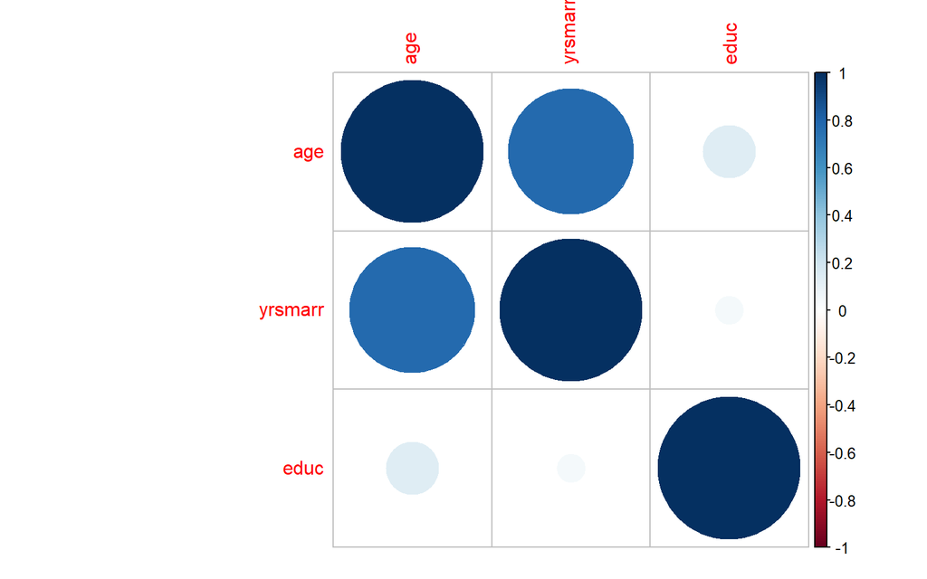

```r
library(corrplot)
affairs_m[,c("age","yrsmarr","educ")] %>% cor() %>% corrplot(method='circle')
```

# Visualisations

## Base R

### Histogram

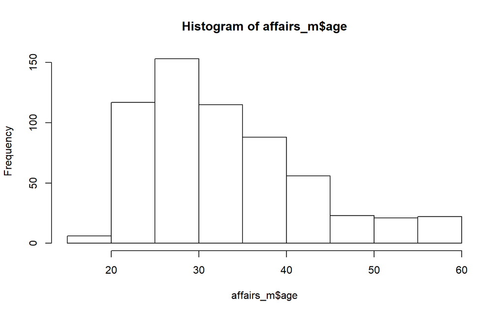

```r
hist(affairs_m$age)
```

### Scatterplot

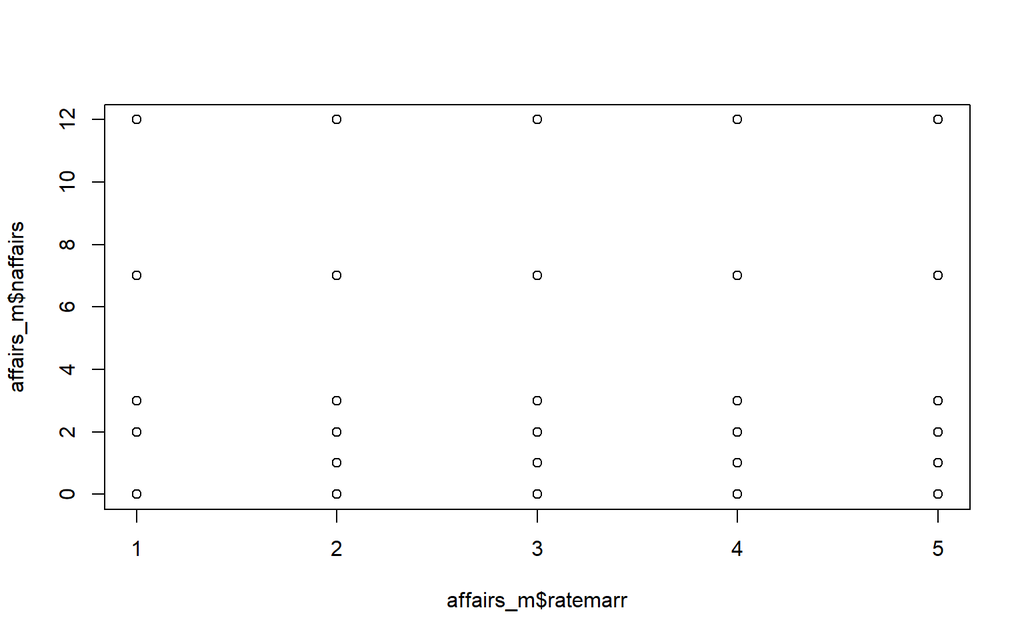

```r
plot(affairs_m$ratemarr,affairs_m$naffairs)
```

### Boxplot

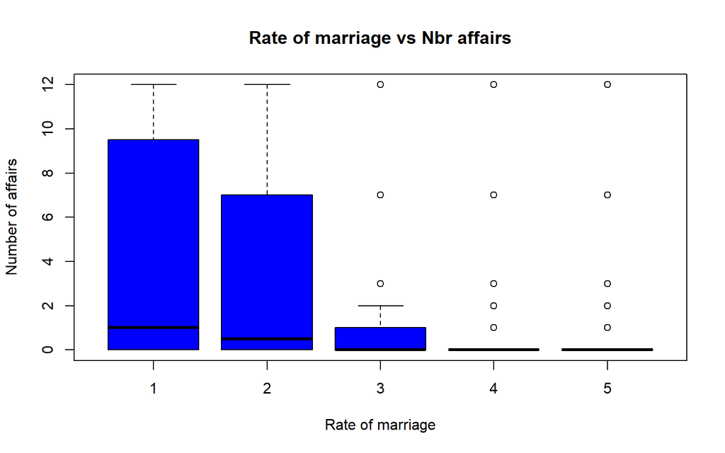

```r
boxplot(affairs_m$naffairs~affairs_m$ratemarr,
        main = "Rate of marriage vs Nbr affairs",
        col="blue",
        xlab = "Rate of marriage",
        ylab = "Number of affairs")
```

### Barchart

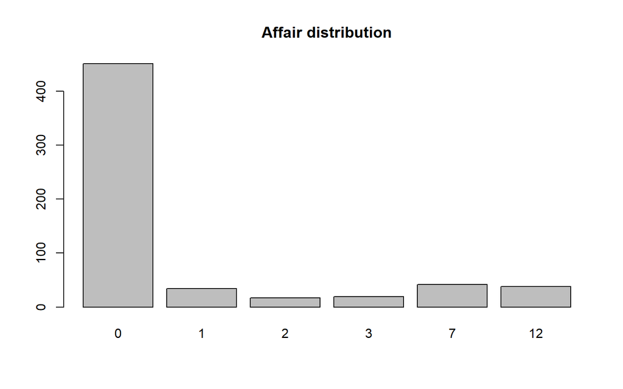

```r
barplot(table(affairs_m$naffairs), main="Affair distribution")
```

### Line chart

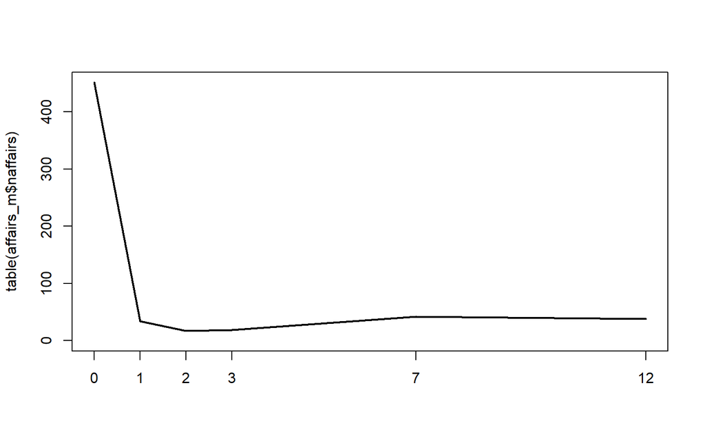

```r
plot(table(affairs_m$naffairs),type="l")
```

### Several plots

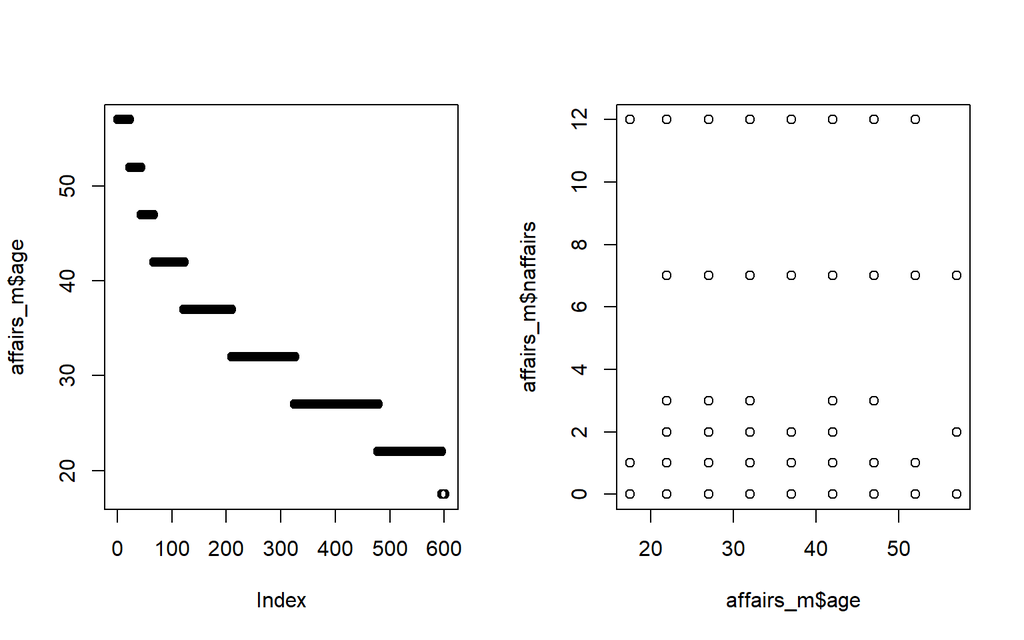

```r
par(mfrow = c(1, 2))
plot(affairs_m$age)
plot(affairs_m$naffairs~affairs_m$age)
```

### Saving charts

```r
dev.copy(png, file = "plot1.png")
# Insert the code of the chart here
dev.off()
```

## Ggplot2 ([ggplot2](http://ggplot2.org/))

```r
library(ggplot2)
```

### Histogram

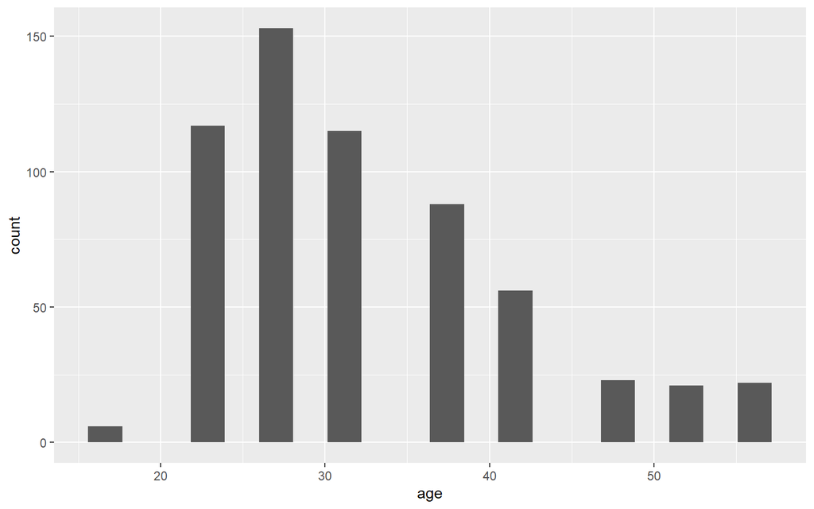

```r
affairs_m %>%
  ggplot(aes(age)) +
  geom_histogram(bins=20)
```

### Scatterplot

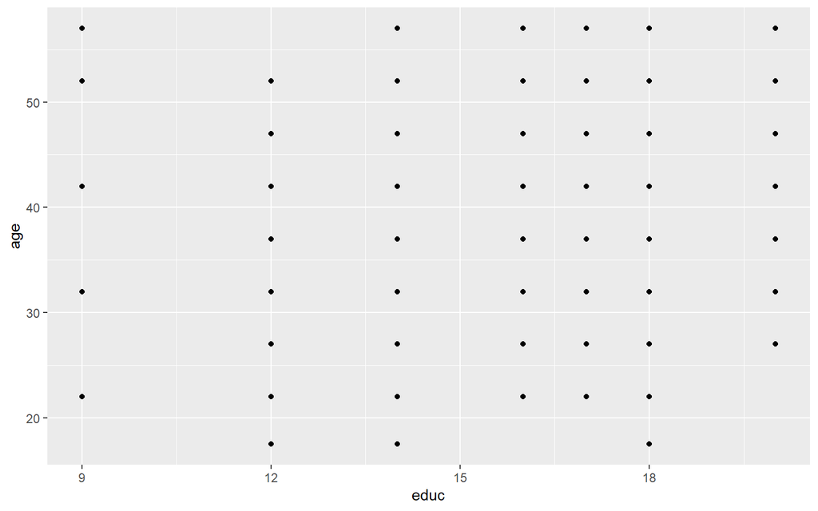

```r
affairs_m %>%
  ggplot(aes(x=educ, y=age)) +
  geom_point()
```

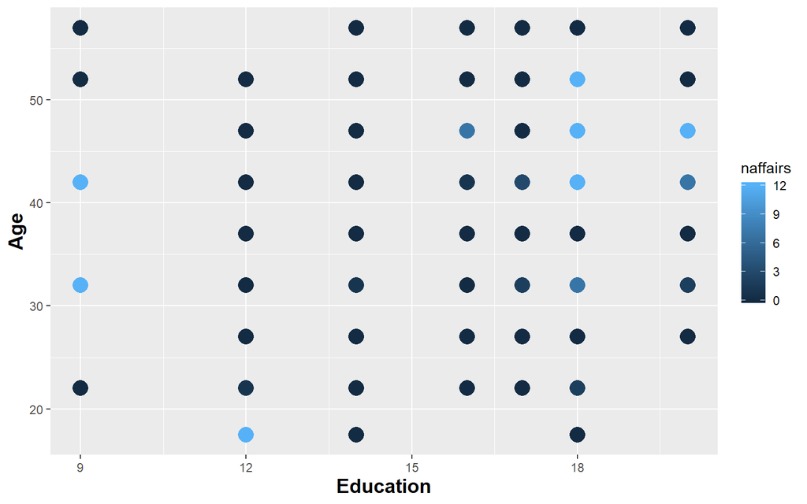

```r
affairs_m %>%
  ggplot(aes(x=educ, y=age, color=naffairs)) +
  geom_point(shape = 16, size = 5) +
  labs(x="Education",y="Age")+
  theme(axis.title = element_text(face="bold",size=14))
```

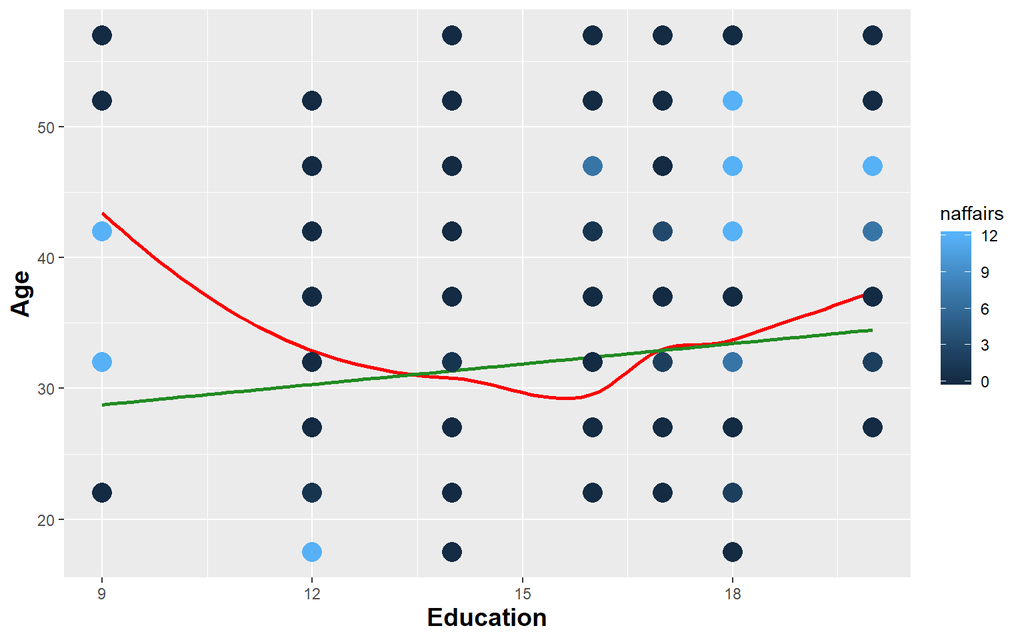

```r
affairs_m %>%
  ggplot(aes(x=educ, y=age, color=naffairs)) +
  geom_smooth(method = "loess", se=FALSE, color="red")+
  geom_smooth(method = "lm", se=FALSE, color="forestgreen")+
  geom_point(shape = 16, size = 5) +
  labs(x="Education",y="Age")+
  theme(axis.title = element_text(face="bold",size=14))
```

### Barchart

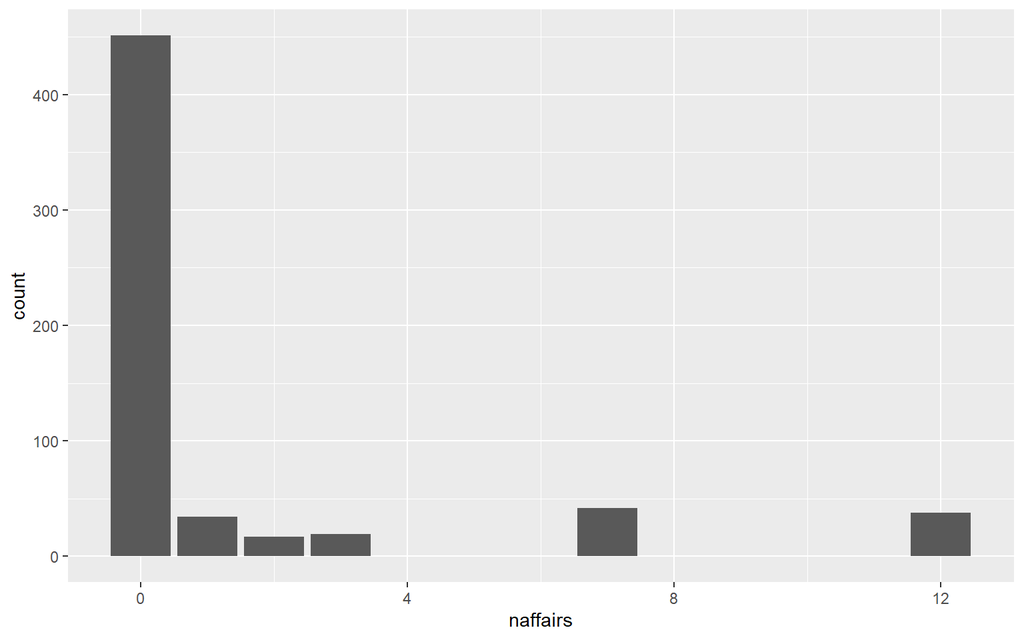

```r
affairs_m %>% group_by(naffairs) %>% summarize(count=n()) %>% data.frame() %>%
  ggplot(aes(x=naffairs, y=count)) +
    geom_bar(stat="identity")
```

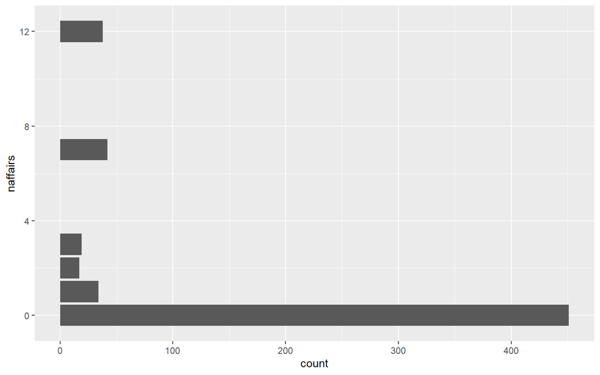

```r
affairs_m %>% group_by(naffairs) %>% summarize(count=n()) %>% data.frame() %>%
  ggplot(aes(x=naffairs, y=count)) +
    geom_bar(stat="identity") +
    coord_flip()
```

### Line chart

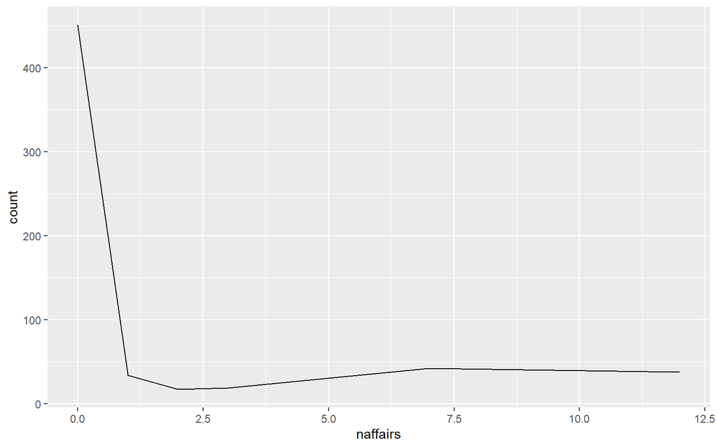

```r
affairs_m %>% group_by(naffairs) %>% summarize(count=n()) %>% data.frame() %>%
  ggplot(aes(x=naffairs, y=count)) +
    geom_line(stat="identity")
```

### Box plot

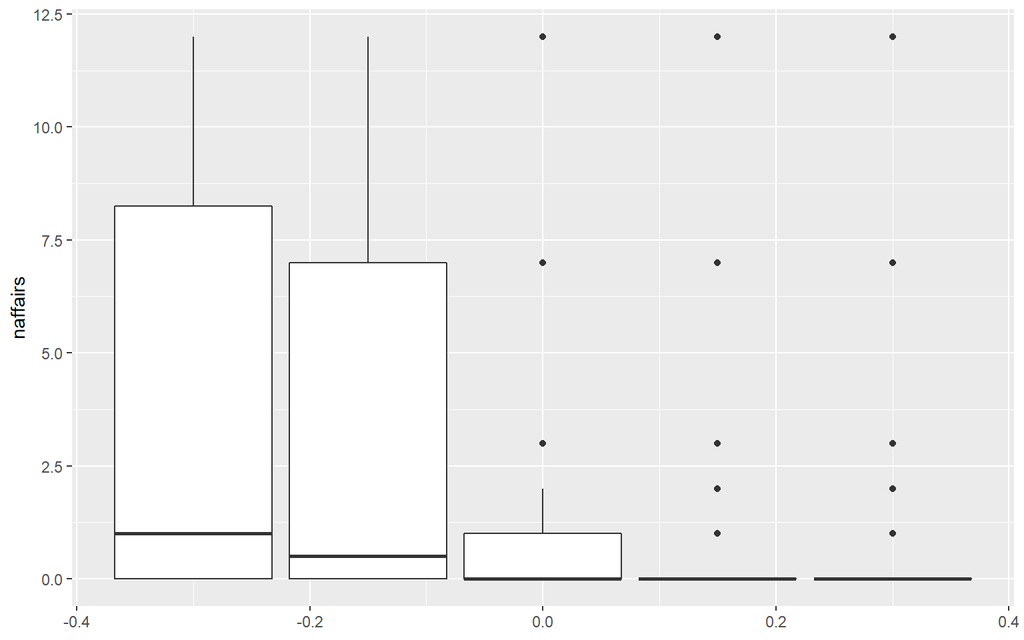

```r
affairs_m %>%
  ggplot(aes(y=naffairs, group=ratemarr)) +
  geom_boxplot()
```

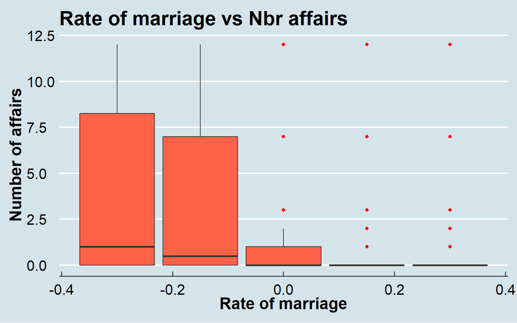

```r
library(ggthemes)
affairs_m %>%
  ggplot(aes(y=naffairs, group=ratemarr)) +
  geom_boxplot(outlier.colour="red",fill="tomato1") +
  labs(title="Rate of marriage vs Nbr affairs",
       x="Rate of marriage",
       y = "Number of affairs")+
  theme_economist()+
  theme(axis.text=element_text(size=16),
        axis.title=element_text(size=18,face="bold"),
        plot.title=element_text(size=22,face = "bold"))
```

### Visualize functions

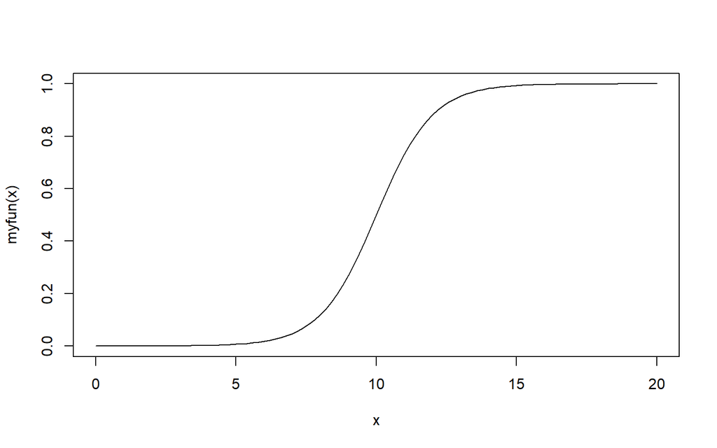

```r
#Logistic function
myfun <- function(xvar) {
  1/(1 + exp(-xvar + 10))
}

#Base R
curve(myfun(x), from=0, to=20)
```

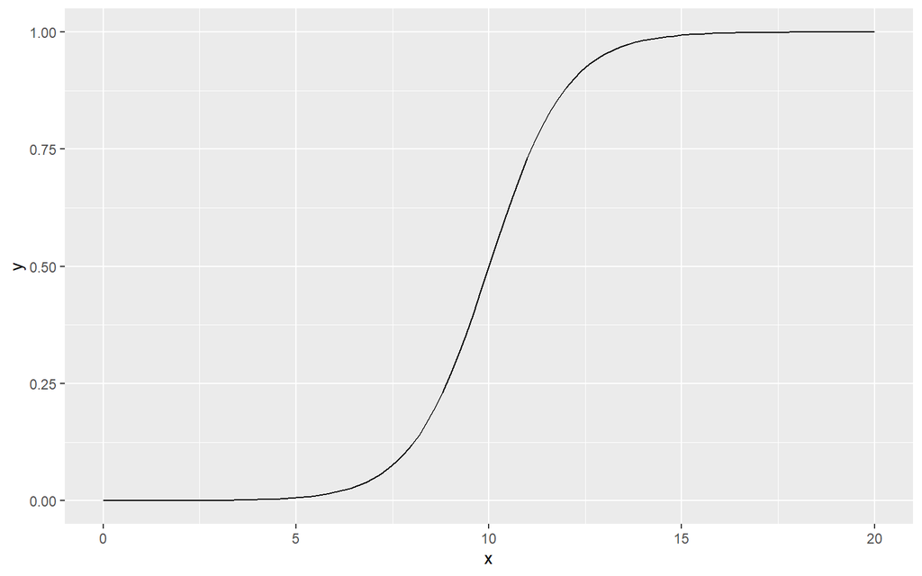

```r
#Ggplot2
data.frame(x=c(0, 20)) %>%
  ggplot(aes(x=x)) +
  stat_function(fun=myfun, geom="line")
```

### Visualize elephant

- https://perfdynamics.blogspot.com/2011/06/winking-pink-elephant.html

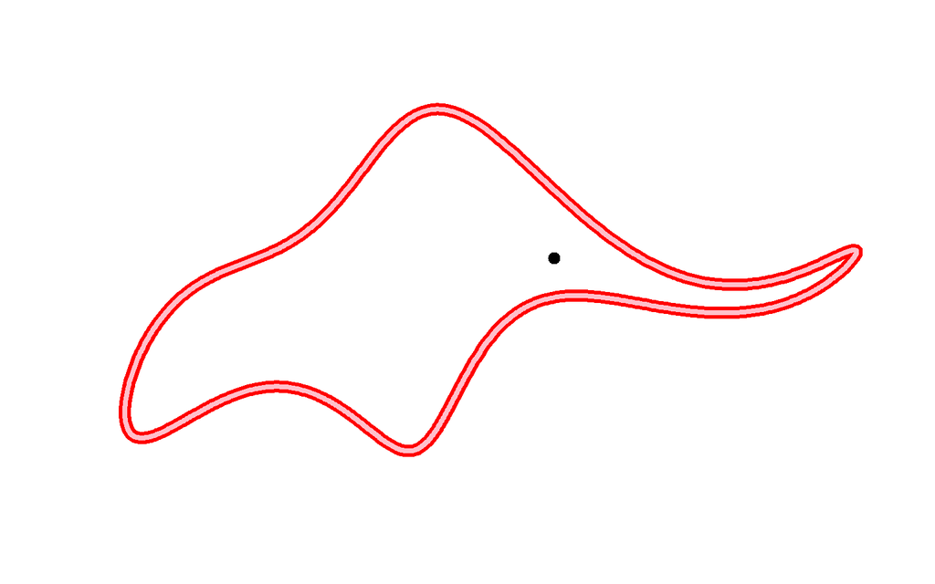

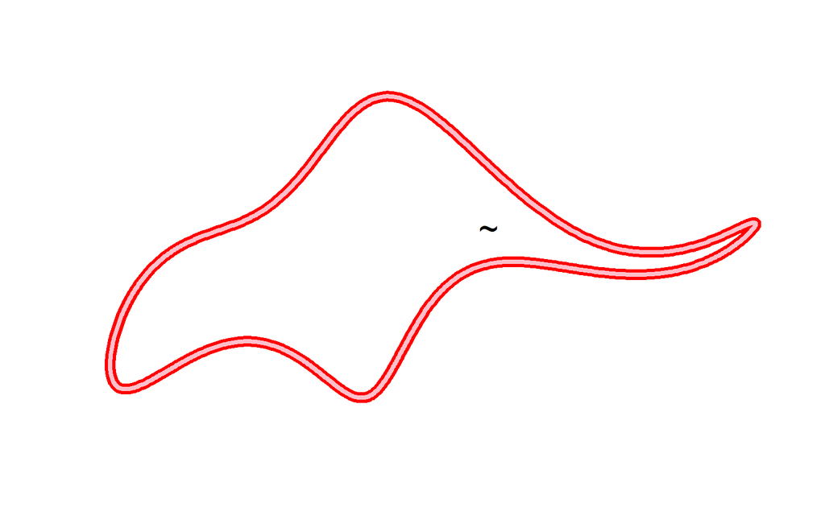

#### For further info about ggplot, check out this page:

- http://r-statistics.co/Complete-Ggplot2-Tutorial-Part1-With-R-Code.html
- http://r-statistics.co/Top50-Ggplot2-Visualizations-MasterList-R-Code.html

István Ilyés

2019 08 28